# Tidymodels

### Imports

```r
library(tidyverse)
library(tidymodels)
library(lubridate)
```

First we will read the data and arrange it by time. Arranging the data by time allows us to easily split the data into temporally continuous train and test sets, avoiding data leakage. In addition, we will use just 10% of the data: this is purely to speed up the computational cost of fitting models, feel free to decrease or increase this as you like. We will also add some time variables (these are not currently implemented in the `recipes` package).

```r
df <- read_csv('data/vw_train.csv') %>%
  sample_frac(0.1, replace = FALSE) %>% # choose 10% of the data
  arrange(timestamp) %>% # sort data by timestamp
  mutate(week = week(timestamp)) %>% # add a week number column
  drop_na(appliances)
```

Next we will split the data into train/test sets, using `initial_time_split()`:

```r
set.seed(123)
data_split <- initial_time_split(df, prop = 3/4)

train <- training(data_split)
test <- testing(data_split)
```

### Creating a recipe

A recipe (created with the `recipe()` function) describes the pre-processing of the data.

```r
rec <-
  recipe(appliances ~ ., data = train) %>% # define formula
  update_role(id, timestamp, new_role = "ID") %>% # set timestamp as ID
  step_mutate(power = current * voltage) %>% # create a new variable: power
  step_other(appliances, threshold = 0.01, skip = TRUE) %>%
  step_dummy(all_nominal_predictors()) %>% # create dummy vars
  step_zv(all_predictors()) %>% # remove zero variance predictors
  step_impute_knn(all_numeric_predictors())  # impute missing values
```

Calling the `rec` object gives a summary of the pre-processing steps:

```r
rec
```

```
## Data Recipe
##
## Inputs:
##
##       role #variables
##         ID          2
##    outcome          1
##  predictor         28
##
## Operations:
##
## Variable mutation for power
## Collapsing factor levels for appliances
## Dummy variables from all_nominal_predictors()
## Zero variance filter on all_predictors()
## K-nearest neighbor imputation for all_numeric_predictors()
```

### Specifying a model

We can specify that we want to tune hyperparameters such as `min_n` and `tree_depth`. Later on, we will use k-fold cross validation to tune these parameters.

```r
model_spec <- boost_tree(mtry = 5,
                         min_n = tune(),
                         tree_depth = tune(),
                         trees = 500) %>%
  set_engine('xgboost') %>%
  set_mode('classification')
```

### Building the workflow

A workflow is used to combine a recipe and a model. The recipe can be used to both fit a model, and use it for predictions, while robustly following all the steps in the recipe to ensure the data is pre-processed correctly.

```r
wflow <- workflow() %>%
  add_recipe(rec) %>%
  add_model(model_spec)
```

### Hyperparameter tuning

##### Resampling

The following step uses either bootstrapping or k-fold CV (AKA v-fold) to create a set of **resamples**. For k-fold CV, k-1 of the resamples are used to fit the model, and the 1 remaining is used for validation. In the case of bootstrapping, each split consists of a fitting dataset (which has the same size as the original data), and a validation set which consists of all the remaining data that was not included in the boostrap resample.

In this case we will `group_vfold_cv()`, which keeps all data of a specified *group* together, and does not split groups across folds. Since the data is time series, this helps mitigate problems of data leakage, where data points from similar time periods find their way into both the training and validation sets. Other resampling methods are commented out below (see the `rsample` documentation).

```r
n_resamples <- 5

# resamples <- bootstraps(data = train, times = n_resamples) # for bootstrap resamples
# resamples <- vfold_cv(train, n_resamples) # for k-fold CV
resamples <- group_vfold_cv(train, week, n_resamples) # for grouped k-fold CV: data points in the same week are kept together
```

##### Grid Search

Now we will tune the hyperparameters with a grid search approach, testing out combinations of hyperparameters. First we will define a grid, giving values for the two hyperparameters we want to tune. If your code is taking a while to run, you may want to reduce the number of hyperparameter settings.

```r
grid <- expand.grid(min_n = c(20, 50, 100), tree_depth = c(10, 20, 50))
grid
```

| min_n | tree_depth |
| --- | --- |
| 20 | 10 |
| 50 | 10 |
| 100 | 10 |
| 20 | 20 |
| 50 | 20 |
| 100 | 20 |
| 20 | 50 |
| 50 | 50 |
| 100 | 50 |

The code below uses our defined grid to search for the optimal combination of hyperparameters. For each combination of parameters, a model will be fit to each of the resamples created above. **Note: this may take a while to run, depending on how many parameter combinations you have selected!**

```r
doParallel::registerDoParallel() # Optional: specifies that we want to use parallel processing
tune_output <-
  tune_grid(wflow,
            resamples = resamples,
            grid = grid)
```

##### Outputting Best Parameters

We can use `show_best()` to output the best hyperparameters:

```r
show_best(tune_output, metric = 'accuracy')
```

| min_n | tree_depth | .metric | .estimator | mean | n | std_err | .config |
| --- | --- | --- | --- | --- | --- | --- | --- |
| 50 | 10 | accuracy | multiclass | 0.7387946 | 5 | 0.02318430 | Preprocessor1_Model2 |
| 100 | 50 | accuracy | multiclass | 0.7385741 | 5 | 0.02381632 | Preprocessor1_Model9 |
| 50 | 50 | accuracy | multiclass | 0.7362220 | 5 | 0.02068053 | Preprocessor1_Model8 |
| 100 | 10 | accuracy | multiclass | 0.7361985 | 5 | 0.02398964 | Preprocessor1_Model3 |
| 100 | 20 | accuracy | multiclass | 0.7353167 | 5 | 0.02641820 | Preprocessor1_Model6 |

And the `autoplot()` function is set up to plot the results of the hyperparameter tuning:

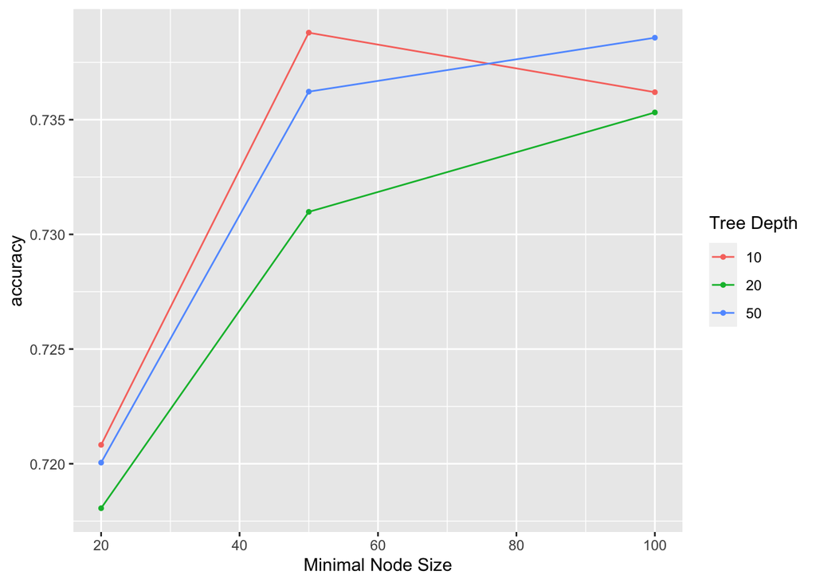

```r
autoplot(tune_output, metric = 'accuracy')
```

### Finalising the model and making predictions

Having tuned the hyperparameters, we can finally train on the entire training dataset and evaluate the model on the held-out test set.

The `finalize_workflow()` function is used to add the tuned parameters to the workflow.

```r
final_wflow <- wflow %>%
  finalize_workflow(select_best(tune_output, metric = 'accuracy'))
final_wflow
```

```
## ══ Workflow ════════════════════════════════════════════════════════════════════
## Preprocessor: Recipe
## Model: boost_tree()
##
## ── Preprocessor ────────────────────────────────────────────────────────────────
## 5 Recipe Steps
##
## • step_mutate()
## • step_other()
## • step_dummy()
## • step_zv()
## • step_impute_knn()
##
## ── Model ───────────────────────────────────────────────────────────────────────
## Boosted Tree Model Specification (classification)
##
## Main Arguments:
##   mtry = 5
##   trees = 500
##   min_n = 50
##   tree_depth = 10
##
## Computational engine: xgboost
```

We can see that `final_wflow` contains all the information in our training pipeline, including pre-processing steps, the model specification and the best hyperparameters.

The workflow can now be trained on the entire training dataset:

```r
final_fit <- fit(final_wflow, train)
```

```
## [16:04:11] WARNING: amalgamation/../src/learner.cc:1095: Starting in XGBoost 1.3.0, the default evaluation metric used with the objective 'multi:softprob' was changed from 'merror' to 'mlogloss'. Explicitly set eval_metric if you'd like to restore the old behavior.
```

And we can make predictions on the training and test sets:

```r
# Make predictions on training data; evaluate accuracy
preds_train <- predict(final_fit, train)
actual_train <- train$appliances
acc_train <- mean(preds_train == actual_train)

# Make predictions on test data; evaluate accuracy
preds_test <- predict(final_fit, test)
actual_test <- test$appliances
acc_test <- mean(preds_test == actual_test)

print(sprintf("Train accuracy: %.4f", acc_train))
```

```
## [1] "Train accuracy: 0.9453"
```

```r
print(sprintf("Test accuracy: %.4f", acc_test))
```

```
## [1] "Test accuracy: 0.7583"
```

There is still a significant amount of overfitting. How could this be avoided?